# mlr3 Workshop

Jakob Richter

September 27, 2019

## mlr3 building blocks

### Read The dataset and remove unsuitable columns

```r
library(data.table)
# Read data and convert strings to factors (as most learners cant handle string columns)
titanic = fread("https://gist.githubusercontent.com/jakob-r/e97e4174534c1d6a3fc95758c6cdc290/raw/fb4795eeb40c03663837a89cf2f97cece52345a2/train.csv", na.strings = "", stringsAsFactors = TRUE)
titanic_pred = fread("https://gist.githubusercontent.com/jakob-r/e97e4174534c1d6a3fc95758c6cdc290/raw/fb4795eeb40c03663837a89cf2f97cece52345a2/test.csv", na.strings = "", stringsAsFactors = TRUE)
str(titanic)
```

```
## Classes 'data.table' and 'data.frame':   891 obs. of  12 variables:
##  $ PassengerId: int  1 2 3 4 5 6 7 8 9 10 ...
##  $ Survived   : int  0 1 1 1 0 0 0 0 1 1 ...
##  $ Pclass     : int  3 1 3 1 3 3 1 3 3 2 ...
##  $ Name       : Factor w/ 891 levels "Abbing, Mr. Anthony",..: 109 191 354 273 16 555 516 625 413 577 ...
##  $ Sex        : Factor w/ 2 levels "female","male": 2 1 1 1 2 2 2 2 1 1 ...
##  $ Age        : num  22 38 26 35 35 NA 54 2 27 14 ...
##  $ SibSp      : int  1 1 0 1 0 0 0 3 0 1 ...
##  $ Parch      : int  0 0 0 0 0 0 0 1 2 0 ...
##  $ Ticket     : Factor w/ 681 levels "110152","110413",..: 524 597 670 50 473 276 86 396 345 133 ...
##  $ Fare       : num  7.25 71.28 7.92 53.1 8.05 ...
##  $ Cabin      : Factor w/ 147 levels "A10","A14","A16",..: NA 82 NA 56 NA NA 130 NA NA NA ...
##  $ Embarked   : Factor w/ 3 levels "C","Q","S": 3 1 3 3 3 2 3 3 3 1 ...
##  - attr(*, ".internal.selfref")=<externalptr>
```

```r
# remove columns that are not directly suitable for prediction
remove_columns = c("PassengerId", "Name", "Ticket", "Cabin")
titanic = titanic[, !(colnames(titanic) %in% remove_columns), with = FALSE]
titanic_pred = titanic_pred[, !(colnames(titanic_pred) %in% remove_columns), with = FALSE]

# convert target column to factor (classification)
titanic[, Survived := as.factor(Survived)]

# build second data.table without columns that contain NAs
na_cols = sapply(colnames(titanic_pred), function(x) any(is.na(titanic[[x]])) || any(is.na(titanic_pred[[x]])))
na_cols = names(na_cols)[na_cols] # extract the names of cols with NAs
titanic_nona = titanic[, !(colnames(titanic) %in% na_cols), with = FALSE]
titanic_nona_pred = titanic_pred[, !(colnames(titanic_pred) %in% na_cols), with = FALSE]
```

### Define an mlr3 Task

```r
# if mlr3 is not installed, run the following line:
# remotes::install_github("mlr-org/mlr3verse")
#library(mlr3verse) # loads all packages mlr3, mlr3tuning, mlr3learners, mlr3pipelines, mlr3viz etc.
library(mlr3)
library(mlr3tuning)
library(mlr3learners)
library(mlr3pipelines)
library(mlr3viz)

# Build Titanic Task
titanic_tsk = TaskClassif$new(id = "titanic", backend = titanic, target = "Survived")
titanic_tsk
```

```
## <TaskClassif:titanic> (891 x 8)
## * Target: Survived
## * Properties: twoclass
## * Features (7):
##   - int (3): Parch, Pclass, SibSp
##   - dbl (2): Age, Fare
##   - fct (2): Embarked, Sex
```

```r
# Build Titanic Task without columns that have NAs
titanic_nona_tsk = TaskClassif$new(id = "titanic_nona", backend = titanic_nona, target = "Survived")
titanic_nona_tsk
```

```
## <TaskClassif:titanic_nona> (891 x 5)
## * Target: Survived
## * Properties: twoclass
## * Features (4):
##   - int (3): Parch, Pclass, SibSp
##   - fct (1): Sex
```

### Define an mlr3 Learner

Define a logistic regression learner

```r
# Check available learners
mlr_learners
```

```
## <DictionaryLearner> with 21 stored values
## Keys: classif.debug, classif.featureless, classif.glmnet,
##   classif.kknn, classif.lda, classif.log_reg, classif.naive_bayes,
##   classif.qda, classif.ranger, classif.rpart, classif.svm,
##   classif.xgboost, regr.featureless, regr.glmnet, regr.kknn,
##   regr.km, regr.lm, regr.ranger, regr.rpart, regr.svm,
##   regr.xgboost
```

```r
# get more informations from the tabular data
as.data.table(mlr_learners)
```

```
##                     key                                    feature_types
##  1:       classif.debug logical,integer,numeric,character,factor,ordered
##  2: classif.featureless logical,integer,numeric,character,factor,ordered
##  3:      classif.glmnet                                  integer,numeric
##  4:        classif.kknn           logical,integer,numeric,factor,ordered
##  5:         classif.lda           logical,integer,numeric,factor,ordered
##  6:     classif.log_reg logical,integer,numeric,character,factor,ordered
##  7: classif.naive_bayes                   logical,integer,numeric,factor
##  8:         classif.qda           logical,integer,numeric,factor,ordered
##  9:      classif.ranger logical,integer,numeric,character,factor,ordered
## 10:       classif.rpart logical,integer,numeric,character,factor,ordered
## 11:         classif.svm                                  integer,numeric
## 12:     classif.xgboost                                  integer,numeric
## 13:    regr.featureless logical,integer,numeric,character,factor,ordered
## 14:         regr.glmnet                                  integer,numeric
```

[output cut: 77 more lines]

```r
lrn = mlr_learners$get("classif.log_reg") # get item from learners directory
lrn = lrn("classif.log_reg") # shorter way
```

### Train the Learner on the Task

```r
lrn$train(task = titanic_nona_tsk)
```

The learner now contains the trained model:

```r
class(lrn$model)
```

```
## [1] "glm" "lm"
```

```r
summary(lrn$model)
```

```
##
## Call:
## stats::glm(formula = task$formula(), family = "binomial", data = task$data())
##
## Deviance Residuals:
##     Min       1Q   Median       3Q      Max
## -2.2794  -0.6849  -0.4761   0.6117   2.5292
##
## Coefficients:
##             Estimate Std. Error z value Pr(>|z|)
## (Intercept)  3.45961    0.31139  11.110   <2e-16 ***
## Parch       -0.05026    0.11041  -0.455   0.6490
## Pclass      -0.93916    0.10653  -8.816   <2e-16 ***
## Sexmale     -2.76236    0.19534 -14.142   <2e-16 ***
## SibSp       -0.23402    0.09919  -2.359   0.0183 *
## ---
## Signif. codes:  0 '***' 0.001 '**' 0.01 '*' 0.05 '.' 0.1 ' ' 1
##
## (Dispersion parameter for binomial family taken to be 1)
##
##     Null deviance: 1186.66  on 890  degrees of freedom
## Residual deviance:  819.11  on 886  degrees of freedom
## AIC: 829.11
##
## Number of Fisher Scoring iterations: 4
```

### Make Predictions

Use the learner that now stores the model to predict the label on the `titanic_nona_pred` data.

```r
# ?Learner
pred = lrn$predict_newdata(task = titanic_nona_tsk, newdata = titanic_nona_pred)
(pred_dt = as.data.table(pred))
```

```
##      row_id truth response
##   1:    892  <NA>        0
##   2:    893  <NA>        1
##   3:    894  <NA>        0
##   4:    895  <NA>        0
##   5:    896  <NA>        1
##  ---
## 414:   1305  <NA>        0
## 415:   1306  <NA>        1
## 416:   1307  <NA>        0
## 417:   1308  <NA>        0
## 418:   1309  <NA>        0
```

```r
table(pred_dt$response)
```

```
##
##   0   1
## 270 148
```

As `titanic_nona_pred` has no labeled observations we can not calculate the performance.

This can only be done on the training data.

Define a indices for the train/test split for the training data:

```r
n = titanic_nona_tsk$nrow
train_inds = sample(seq_len(n), size = round(n * 0.66))
test_inds = setdiff(seq_len(n), train_inds)
```

Now we can predict on data with known labels and calculate various performance measures:

```r
lrn$predict_type
```

```
## [1] "response"
```

```r
lrn$predict_type = "prob" # change predict type to probabilities as some measures need probabilities

# train the model on training indices
lrn$train(task = titanic_nona_tsk, row_ids = train_inds)

# generate the prediction
pred = lrn$predict(task = titanic_nona_tsk, row_ids = test_inds)

# chose different measures to score the prediction
mlr_measures
```

```
## <DictionaryMeasure> with 31 stored values
## Keys: classif.acc, classif.auc, classif.ce, classif.costs,
##   classif.dor, classif.f_score, classif.fdr, classif.fn,
##   classif.fnr, classif.for, classif.fp, classif.fpr, classif.npv,
##   classif.ppv, classif.precision, classif.recall,
##   classif.sensitivity, classif.specificity, classif.tn,
##   classif.tnr, classif.tp, classif.tpr, debug, oob_error,
##   regr.mae, regr.mse, regr.rmse, selected_features, time_both,
##   time_predict, time_train
```

```r
msrs = lapply(c("classif.acc", "classif.auc", "time_train"), msr)
pred$score(measures = msrs)
```

```
## classif.acc classif.auc  time_train
##   0.8052805   0.8502313   0.0000000
```

## Resampling

To automate the test train split we can use resample.

Therefore we need a resampling strategy.

```r
# show available resampling objects
mlr_resamplings
```

```
## <DictionaryResampling> with 6 stored values
## Keys: bootstrap, custom, cv, holdout, repeated_cv, subsampling
```

```r
# load cross validation
rds = rsmp("cv")
# check how many folds
rds$param_set$values
```

```
## $folds
## [1] 10
```

We want to do a 5-fold cross-validation:

```r
# change the folds parameter of the resampling description object
rds$param_set$values$folds = 5

# execute resampling
res = resample(task = titanic_nona_tsk, learner = lrn, resampling = rds)

# calculate performance measures with previously defined measures
res$score(msrs)
```

```
##             task      task_id                learner      learner_id
## 1: <TaskClassif> titanic_nona <LearnerClassifLogReg> classif.log_reg
## 2: <TaskClassif> titanic_nona <LearnerClassifLogReg> classif.log_reg
## 3: <TaskClassif> titanic_nona <LearnerClassifLogReg> classif.log_reg
## 4: <TaskClassif> titanic_nona <LearnerClassifLogReg> classif.log_reg
## 5: <TaskClassif> titanic_nona <LearnerClassifLogReg> classif.log_reg
##        resampling resampling_id iteration prediction classif.acc
## 1: <ResamplingCV>            cv         1     <list>   0.8268156
## 2: <ResamplingCV>            cv         2     <list>   0.7752809
## 3: <ResamplingCV>            cv         3     <list>   0.8202247
## 4: <ResamplingCV>            cv         4     <list>   0.7696629
## 5: <ResamplingCV>            cv         5     <list>   0.8146067
##    classif.auc time_train
## 1:   0.8608903       0.00
## 2:   0.8040674       0.02
## 3:   0.8325893       0.00
## 4:   0.8370582       0.01
## 5:   0.8361629       0.01
```

```r
res$aggregate(msrs)
```

```
## classif.acc classif.auc  time_train
##   0.8013182   0.8341536   0.0080000
```

## Benchmarking

We are going to benchmark multiple learners on the titanic task. Learners that cannot handle missing values will be evaluated on the `titanic_nona_tsk` task. Learners that can handle missing values will be evaluated on the `titanic_tsk` task. The benchmark will use the previously defined 5-fold cross-validation.

```r
# show learners with properties (again)
as.data.table(mlr_learners)
```

```
##                     key                                    feature_types
##  1:       classif.debug logical,integer,numeric,character,factor,ordered
##  2: classif.featureless logical,integer,numeric,character,factor,ordered
##  3:      classif.glmnet                                  integer,numeric
##  4:        classif.kknn           logical,integer,numeric,factor,ordered
##  5:         classif.lda           logical,integer,numeric,factor,ordered
##  6:     classif.log_reg logical,integer,numeric,character,factor,ordered
##  7: classif.naive_bayes                   logical,integer,numeric,factor
##  8:         classif.qda           logical,integer,numeric,factor,ordered
##  9:      classif.ranger logical,integer,numeric,character,factor,ordered
## 10:       classif.rpart logical,integer,numeric,character,factor,ordered
## 11:         classif.svm                                  integer,numeric
## 12:     classif.xgboost                                  integer,numeric
## 13:    regr.featureless logical,integer,numeric,character,factor,ordered
## 14:         regr.glmnet                                  integer,numeric
```

[output cut: 77 more lines]

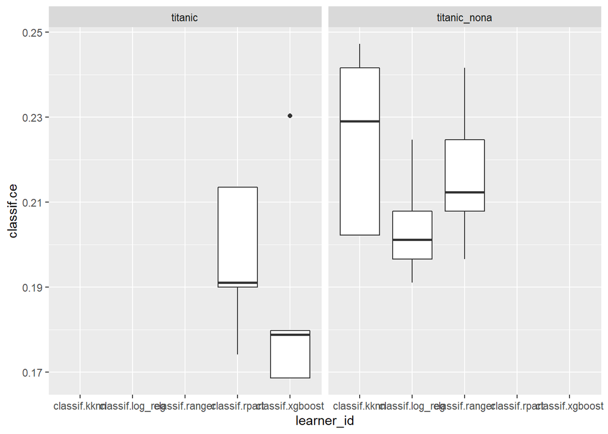

```r
# experiments with learners that cannot handle NAs
design_nona = benchmark_grid(
  tasks = titanic_nona_tsk,
  learners = lapply(c("classif.log_reg", "classif.kknn", "classif.ranger"), lrn),
  resamplings = rds)

# experiments with learners that can handle NAs
design_with_na = benchmark_grid(
  tasks = titanic_tsk,
  learners = lapply(c("classif.xgboost", "classif.rpart"), lrn),
  resamplings = rds)

# simply rbind both designs
design_complete = rbind(design_nona, design_with_na)

# conduct benchmark
res = benchmark(design = design_complete)

# plot benchmark results
mlr3viz::autoplot(res)
```